# DSC540 Project 3

DePaul University  
Ilyas Ustun, PhD  
Chicago, IL

[figure not shown]

## Import Libraries

**Import the usual libraries for pandas and plotting, and sklearn.**

```python
import pandas as pd
import numpy as np
import matplotlib.pyplot as plt
import seaborn as sns

from sklearn import metrics
```

```python
import sklearn
sklearn.__version__
```

```
'0.21.3'
```

```python
pd.set_option('display.max_columns', 100)
```

## Q1 [10]

- Read in the dataset
- How many rows and variables are there?

## Get the Data

**Use pandas to read in the datasets as a dataframe.**

```python
df = pd.read_csv('gas_emissions.csv')
```

```python
df.head()
```

|  | AT | AP | AH | AFDP | GTEP | TIT | TAT | TEY | CDP | CO | NOX |
| --- | --- | --- | --- | --- | --- | --- | --- | --- | --- | --- | --- |
| 0 | 1.95320 | 1020.1 | 84.985 | 2.5304 | 20.116 | 1048.7 | 544.92 | 116.27 | 10.799 | 7.4491 | 113.250 |
| 1 | 1.21910 | 1020.1 | 87.523 | 2.3937 | 18.584 | 1045.5 | 548.50 | 109.18 | 10.347 | 6.4684 | 112.020 |
| 2 | 0.94915 | 1022.2 | 78.335 | 2.7789 | 22.264 | 1068.8 | 549.95 | 125.88 | 11.256 | 3.6335 | 88.147 |
| 3 | 1.00750 | 1021.7 | 76.942 | 2.8170 | 23.358 | 1075.2 | 549.63 | 132.21 | 11.702 | 3.1972 | 87.078 |
| 4 | 1.28580 | 1021.6 | 76.732 | 2.8377 | 23.483 | 1076.2 | 549.68 | 133.58 | 11.737 | 2.3833 | 82.515 |

#### What is the average value of AP for those points who have CO levels above 3 mg/m3?

```python
df.groupby('CO').filter(lambda group: group.size>3)['AP'].mean()
```

```
1014.5091102383524
```

#### Create a correlation map between the variables. Which variables have high correlation?

```python
corr = df.corr()
```

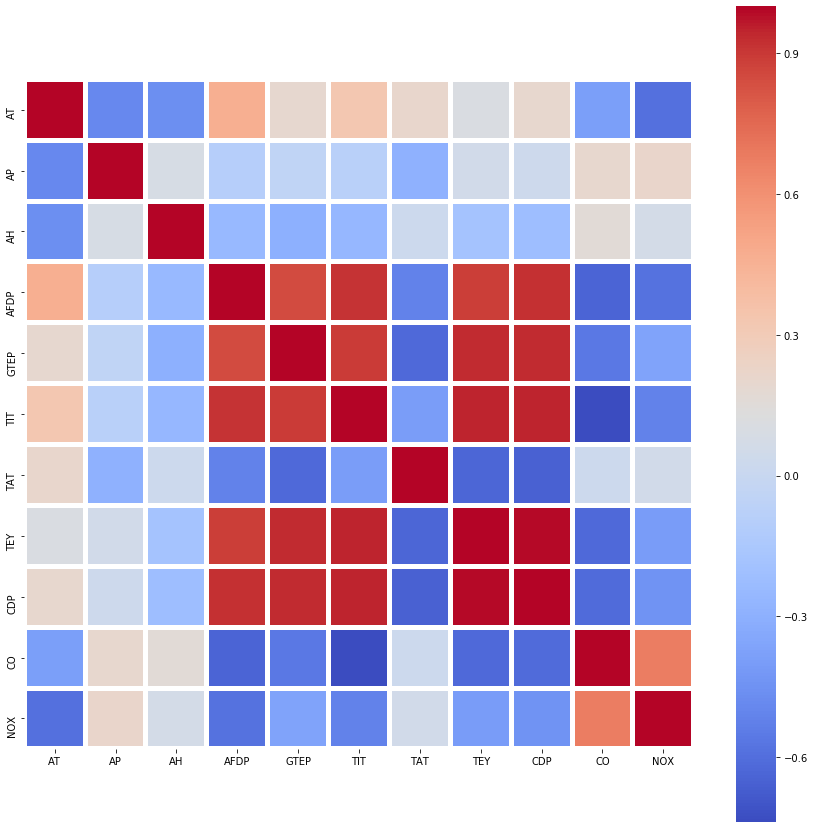

```python
f,ax=plt.subplots(figsize=(15,15))
sns.heatmap(corr,cbar = True, square = True, annot = False, fmt = '.1f',xticklabels = True, yticklabels=True, cmap = 'coolwarm',linewidths = 4,ax=ax)
```

**Highly Correlated Pairs:**

1. AFDP & GTEP
2. AFDP & TIT
3. AFDP & TEY
4. AFDP & CDP
5. TEY & CDP
6. CD & NOX

#### Create a scatter plot of 'TEY' vs 'CDP'

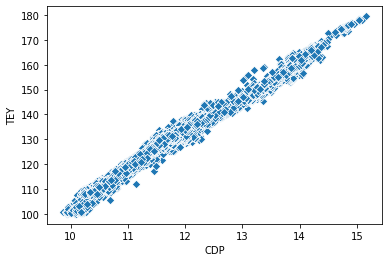

```python
sns.scatterplot('CDP','TEY',data = df,marker = 'D')
plt.show()
```

#### Create histograms for CO and NOX.

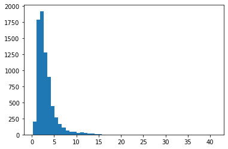

```python
df['CO'].hist(bins = 50,grid = False)
plt.show()
```

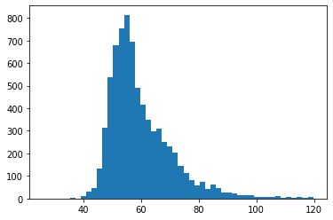

```python
df['NOX'].hist(bins = 50,grid = False)
plt.show()
```

### Prepare data from machine learning

We will predict CO using all the other variables. The NOX will not be used. That is another emission gas that can be predicted as well.

```python
y = df.CO
X = df.drop(['CO', 'NOX'], axis=1)
```

```python
from sklearn.model_selection import train_test_split
X_train, X_test, y_train, y_test = train_test_split(X, y, test_size=0.10, random_state=555)
X_train, X_val, y_train, y_val = train_test_split(X_train, y_train, test_size=0.30, random_state=555)
```

```python
# Standardization of the data
from sklearn.preprocessing import StandardScaler
ss = StandardScaler()
ss.fit(X_train)
X_train = ss.transform(X_train)
X_val = ss.transform(X_val)
X_test = ss.transform(X_test)
```

```python
X_train.shape
```

```
(4651, 9)
```

```python
X_val.shape
```

```
(1994, 9)
```

```python
X_test.shape
```

```
(739, 9)
```

## Q2 [10]

- Apply Linear Regression. Predict CO emission using other variables.
  - What is the model $R^2$ (on training data)?
  - What is the $R^2$ on validation data?
  - What is the Root Mean Squared Error (RMSE) on training data?
  - What is the RMSE on validation data?
> - $R^2$ higher is better. ($R^2$ is % variation in data being explained)
> - RMSE lower is better. (RMSE is error, meaning the difference between predictions and actual data)

Hint:

- You can use the `r2_score` and `mean_squared_error` methods in `sklearn.metrics`.
- You need to take the square root of Mean Squared Error to get to RMSE. (MSE $->$ square root $->$ RMSE)

```python
from sklearn import metrics
```

```python
from math import *
from sklearn.metrics import mean_squared_error
from sklearn.metrics import r2_score
import statsmodels
```

```python
from sklearn.linear_model import LinearRegression
```

```python
reg = LinearRegression()
```

```python
reg.fit(X_train, y_train)
```

```
LinearRegression(copy_X=True, fit_intercept=True, n_jobs=None, normalize=False)
```

```python
p_train = reg.predict(X_train)
reg_rmse_train = sqrt(mean_squared_error(y_train,p_train))
reg_r2_train = r2_score(y_train,p_train)
print('RMSE on Training Data:\n',round(reg_rmse_train,2))
print('R-squared on Training Set:\n',reg_r2_train)
```

```
RMSE on Training Data:
 1.31
R-squared on Training Set:
 0.6468752136774542
```

```python
p_validation = reg.predict(X_val)
reg_rmse_test = sqrt(mean_squared_error(y_val,p_validation))
reg_r2_test = r2_score(y_val,p_validation)
print('RMSE on Testing Data:\n',round(reg_rmse_test,2))
print('R-squared on Testing Set:\n',reg_r2_test)
```

```
RMSE on Testing Data:
 1.39
R-squared on Testing Set:
 0.6290818432737131
```

## Q3 [10]

- Apply Random Forest Regression with 100 trees. Predict CO emission using other variables.
  - What is the model $R^2$?
  - What is the $R^2$ on validation data?
  - What is the RMSE on training data?
  - What is the RMSE on validation data?
- Is training and validation score close? If not what might be the problem?
- If there is a large gap, try to decrease the gap by changing some hyperparameters of the Random Forest model. (In this analysis, any difference more than 0.10 $R^2$ difference can be assumed to be large.)
  - Once you reach a difference of less than or close to 0.10 between training $R^2$ and validation $R^2$ you can stop.
  - During this process your training score will probably decrease, and that is OK.

```python
from sklearn.ensemble import RandomForestRegressor
```

```python
reg = RandomForestRegressor(n_estimators=100)
```

```python
reg.fit(X_train, y_train)
```

```
RandomForestRegressor(bootstrap=True, criterion='mse', max_depth=None,
                      max_features='auto', max_leaf_nodes=None,
                      min_impurity_decrease=0.0, min_impurity_split=None,
                      min_samples_leaf=1, min_samples_split=2,
                      min_weight_fraction_leaf=0.0, n_estimators=100,
                      n_jobs=None, oob_score=False, random_state=None,
                      verbose=0, warm_start=False)
```

```python
p_train = reg.predict(X_train)
rf_rmse_train = sqrt(mean_squared_error(y_train,p_train))
rf_r2_train = r2_score(y_train,p_train)
print('RMSE on Training Data:\n',round(rf_rmse_train,2))
print('R-squared on Training Set:\n',rf_r2_train)
```

```
RMSE on Training Data:
 0.45
R-squared on Training Set:
 0.9594121515222038
```

```python
p_validation = reg.predict(X_val)
rf_rmse_test = sqrt(mean_squared_error(y_val,p_validation))
rf_r2_test = r2_score(y_val,p_validation)
print('RMSE on Testing Data:\n',round(rf_rmse_test,2))
print('R-squared on Testing Set:\n',rf_r2_test)
```

```
RMSE on Testing Data:
 1.14
R-squared on Testing Set:
 0.7493450154104488
```

**Is training and validation score close? If not what might be the problem?**

The score is not very close. This might be due to the fact that we are overfitting the data on our training samples.

**Tuning Random Forest Regression Hyperparameters - Application (Below)**

```python
reg = RandomForestRegressor()
```

```python
parameter = {'min_samples_split':[2,200,500],'max_depth':[10,50,100],'n_estimators':[10,90,180]}
```

```python
from sklearn.model_selection import GridSearchCV
grid_cv_forest_reg = GridSearchCV(estimator = reg ,param_grid = parameter,cv = 5) #depth = parameter
```

```python
grid_cv_forest_reg.fit(X_train, y_train)
```

```
GridSearchCV(cv=5, error_score='raise-deprecating',
             estimator=RandomForestRegressor(bootstrap=True, criterion='mse',
                                             max_depth=None,
                                             max_features='auto',
                                             max_leaf_nodes=None,
                                             min_impurity_decrease=0.0,
                                             min_impurity_split=None,
                                             min_samples_leaf=1,
                                             min_samples_split=2,
                                             min_weight_fraction_leaf=0.0,
                                             n_estimators='warn', n_jobs=None,
                                             oob_score=False, random_state=None,
                                             verbose=0, warm_start=False),
             iid='warn', n_jobs=None,
             param_grid={'max_depth': [10, 50, 100],
                         'min_samples_split': [2, 200, 500],
                         'n_estimators': [10, 90, 180]},
             pre_dispatch='2*n_jobs', refit=True, return_train_score=False,
             scoring=None, verbose=0)
```

```python
grid_cv_forest_reg.cv_results_
```

[output not shown]

[output cut: 68 more lines]

[output not shown]

```python
grid_cv_forest_reg.best_estimator_
```

```
RandomForestRegressor(bootstrap=True, criterion='mse', max_depth=10,
                      max_features='auto', max_leaf_nodes=None,
                      min_impurity_decrease=0.0, min_impurity_split=None,
                      min_samples_leaf=1, min_samples_split=2,
                      min_weight_fraction_leaf=0.0, n_estimators=90,
                      n_jobs=None, oob_score=False, random_state=None,
                      verbose=0, warm_start=False)
```

```python
best_rf_reg = RandomForestRegressor(bootstrap=True, criterion='mse', max_depth=10,
                      max_features='auto', max_leaf_nodes=None,
                      min_impurity_decrease=0.0, min_impurity_split=None,
                      min_samples_leaf=1, min_samples_split=47,
                      min_weight_fraction_leaf=0.0, n_estimators=10,
                      n_jobs=None, oob_score=False, random_state=None,
                      verbose=0, warm_start=False)
```

```python
best_rf_reg.fit(X_train,y_train)
```

```
RandomForestRegressor(bootstrap=True, criterion='mse', max_depth=10,
                      max_features='auto', max_leaf_nodes=None,
                      min_impurity_decrease=0.0, min_impurity_split=None,
                      min_samples_leaf=1, min_samples_split=47,
                      min_weight_fraction_leaf=0.0, n_estimators=10,
                      n_jobs=None, oob_score=False, random_state=None,
                      verbose=0, warm_start=False)
```

```python
p_train = best_rf_reg.predict(X_train)
rf_rmse_train_best = sqrt(mean_squared_error(y_train,p_train))
rf_r2_train_best = r2_score(y_train,p_train)
print('RMSE on Training Data:\n',round(rf_rmse_train_best,2))
print('R-squared on Training Set:\n',rf_r2_train_best)
```

```
RMSE on Training Data:
 0.93
R-squared on Training Set:
 0.8217931453931763
```

```python
p_validation = best_rf_reg.predict(X_val)
rf_rmse_test_best = sqrt(mean_squared_error(y_val,p_validation))
rf_r2_test_best = r2_score(y_val,p_validation)
print('RMSE on Testing Data:\n',round(rf_rmse_test_best,2))
print('R-squared on Testing Set:\n',rf_r2_test_best)
```

```
RMSE on Testing Data:
 1.18
R-squared on Testing Set:
 0.7330660711403466
```

```python
rf_r2_train_best - rf_r2_test_best
```

```
0.08872707425282966
```

**Tuning Random Forest Regression Hyperparameters - Results**

Through changing the min_sample_splits, I was able to combat overfitting, and bring the r2 down on the training set. This did result in a near doubling of the RMSE though. The RMSE is now closer to what is on the testing set. The tuning of the parameters did not impact the testing set dramatically.

## Q4 [10]

- Apply Support Vector Regression. Predict CO emission using other variables.
  - What is the model $R^2$?
  - What is the $R^2$ on validation data?
  - What is the RMSE on training data?
  - What is the RMSE on validation data?
- Apply the process above using **linear kernel SVR**, **polynomial kernel SVR**, and **RBF kernel SVR**.
- Take RBF Kernel SVM and perform some hyperparameter tuning. See if you can increase the $R^2$ score.
  - During this process this make sure it doesn't overfit the data.

```python
from sklearn.svm import SVR
```

### Linear SVM Regressor

```python
reg = SVR(kernel='linear')
```

```python
reg.fit(X_train, y_train)
```

```
SVR(C=1.0, cache_size=200, coef0=0.0, degree=3, epsilon=0.1,
    gamma='auto_deprecated', kernel='linear', max_iter=-1, shrinking=True,
    tol=0.001, verbose=False)
```

```python
p_train = reg.predict(X_train)
svrlin_rmse_train = sqrt(mean_squared_error(y_train,p_train))
svrlin_r2_train = r2_score(y_train,p_train)
print('RMSE on Training Data:\n',round(svrlin_rmse_train,2))
print('R-squared on Training Set:\n',svrlin_r2_train)
```

```
RMSE on Training Data:
 1.37
R-squared on Training Set:
 0.6142889670063518
```

```python
p_validation = reg.predict(X_val)
svrlin_rmse_test = sqrt(mean_squared_error(y_val,p_validation))
svrlin_r2_test = r2_score(y_val,p_validation)
print('RMSE on Testing Data:\n',round(svrlin_rmse_test,2))
print('R-squared on Testing Set:\n',svrlin_r2_test)
```

```
RMSE on Testing Data:
 1.46
R-squared on Testing Set:
 0.5923266225681006
```

### Polynomial Kernel SVM Regressor

```python
from sklearn.svm import SVR
```

```python
reg = SVR(kernel='poly')
```

```python
reg.fit(X_train, y_train)
```

```
SVR(C=1.0, cache_size=200, coef0=0.0, degree=3, epsilon=0.1,
    gamma='auto_deprecated', kernel='poly', max_iter=-1, shrinking=True,
    tol=0.001, verbose=False)
```

```python
p_train = reg.predict(X_train)
svrpoly_rmse_train = sqrt(mean_squared_error(y_train,p_train))
svrpoly_r2_train = r2_score(y_train,p_train)
print('RMSE on Training Data:\n',round(svrpoly_rmse_train,2))
print('R-squared on Training Set:\n',svrpoly_r2_train)
```

```
RMSE on Training Data:
 1.17
R-squared on Training Set:
 0.7220653248687375
```

```python
p_validation = reg.predict(X_val)
svrpoly_rmse_test = sqrt(mean_squared_error(y_val,p_validation))
svrpoly_r2_test = r2_score(y_val,p_validation)
print('RMSE on Testing Data:\n',round(svrpoly_rmse_test,2))
print('R-squared on Testing Set:\n',svrpoly_r2_test)
```

```
RMSE on Testing Data:
 1.25
R-squared on Testing Set:
 0.6988221760466373
```

### RBF Kernel SVM Regressor

```python
from sklearn.svm import SVR
```

```python
reg = SVR(kernel='rbf')
```

```python
reg.fit(X_train, y_train)
```

```
SVR(C=1.0, cache_size=200, coef0=0.0, degree=3, epsilon=0.1,
    gamma='auto_deprecated', kernel='rbf', max_iter=-1, shrinking=True,
    tol=0.001, verbose=False)
```

```python
p_train = reg.predict(X_train)
svrrbf_rmse_train = sqrt(mean_squared_error(y_train,p_train))
svrrbf_r2_train = r2_score(y_train,p_train)
print('RMSE on Training Data:\n',round(svrrbf_rmse_train,2))
print('R-squared on Training Set:\n',svrrbf_r2_train)
```

```
RMSE on Training Data:
 1.1
R-squared on Training Set:
 0.7537814347693681
```

```python
p_validation = reg.predict(X_val)
svrrbf_rmse_test = sqrt(mean_squared_error(y_val,p_validation))
svrrbf_rmse_test = r2_score(y_val,p_validation)
print('RMSE on Testing Data:\n',round(svrrbf_rmse_test,2))
print('R-squared on Testing Set:\n',svrrbf_rmse_test)
```

```
RMSE on Testing Data:
 0.72
R-squared on Testing Set:
 0.7239434577070454
```

**RBF Kernel Parameter Optimization - Application**

```python
reg = SVR(kernel='rbf')
```

```python
parameter = {"C": [20],"gamma":[.1,.15,.30,10],"degree":[.0001,.001,.01]}
```

```python
grid_cv_svrrbf_reg = GridSearchCV(estimator = reg ,param_grid = parameter,cv = 5) #depth = parameter
```

```python
grid_cv_svrrbf_reg.fit(X_train, y_train)
```

```
GridSearchCV(cv=5, error_score='raise-deprecating',
             estimator=SVR(C=1.0, cache_size=200, coef0=0.0, degree=3,
                           epsilon=0.1, gamma='auto_deprecated', kernel='rbf',
                           max_iter=-1, shrinking=True, tol=0.001,
                           verbose=False),
             iid='warn', n_jobs=None,
             param_grid={'C': [20], 'degree': [0.0001, 0.001, 0.01],
                         'gamma': [0.1, 0.15, 0.3, 10]},
             pre_dispatch='2*n_jobs', refit=True, return_train_score=False,
             scoring=None, verbose=0)
```

```python
grid_cv_svrrbf_reg.cv_results_
```

[output not shown]

[output cut: 8 more lines]

```
        0.84591706, 0.83427679, 0.52437062, 0.85269221, 0.84591706,
        0.83427679, 0.52437062]),
 'split3_test_score': array([0.60844167, 0.60755203, 0.60267992, 0.401503  , 0.60844167,
        0.60755203, 0.60267992, 0.401503  , 0.60844167, 0.60755203,
        0.60267992, 0.401503  ]),
 'split4_test_score': array([0.76717611, 0.76108283, 0.7572052 , 0.45641408, 0.76717611,
        0.76108283, 0.7572052 , 0.45641408, 0.76717611, 0.76108283,
        0.7572052 , 0.45641408]),
 'mean_test_score': array([0.75897162, 0.75693184, 0.75226621, 0.46381952, 0.75897162,
        0.75693184, 0.75226621, 0.46381952, 0.75897162, 0.75693184,
        0.75226621, 0.46381952]),
 'std_test_score': array([0.08732954, 0.08670568, 0.08651877, 0.05262637, 0.08732954,
        0.08670568, 0.08651877, 0.05262637, 0.08732954, 0.08670568,
        0.08651877, 0.05262637]),
 'rank_test_score': array([ 1,  4,  7, 10,  1,  4,  7, 10,  1,  4,  7, 10])}
```

```python
grid_cv_svrrbf_reg.best_estimator_
```

```
SVR(C=20, cache_size=200, coef0=0.0, degree=0.0001, epsilon=0.1, gamma=0.1,
    kernel='rbf', max_iter=-1, shrinking=True, tol=0.001, verbose=False)
```

```python
svr_reg_best = grid_cv_svrrbf_reg.best_estimator_
```

```python
svr_reg_best.fit(X_train,y_train)
```

```
SVR(C=20, cache_size=200, coef0=0.0, degree=0.0001, epsilon=0.1, gamma=0.1,
    kernel='rbf', max_iter=-1, shrinking=True, tol=0.001, verbose=False)
```

```python
p_train = svr_reg_best.predict(X_train)
svrrbf_rmse_train_best = sqrt(mean_squared_error(y_train,p_train))
svrrbf_r2_train_best = r2_score(y_train,p_train)
print('RMSE on Training Data:\n',round(svrrbf_rmse_train_best,2))
print('R-squared on Training Set:\n',svrrbf_r2_train_best)
```

```
RMSE on Training Data:
 1.06
R-squared on Training Set:
 0.7715013438939493
```

```python
p_validation = svr_reg_best.predict(X_val)
svrrbf_rmse_test_best = sqrt(mean_squared_error(y_val,p_validation))
svrrbf_r2_test_best = r2_score(y_val,p_validation)
print('RMSE on Testing Data:\n',round(svrrbf_rmse_test_best,2))
print('R-squared on Testing Set:\n',svrrbf_r2_test_best)
```

```
RMSE on Testing Data:
 1.18
R-squared on Testing Set:
 0.7348406867576343
```

## Q5 [10]

- Apply PCA and transform the data.
- Take only the first 4 principal components.
- Use the PCA transformed data to perform regression.
- Apply Linear Regression, Random Forest Regression, and RBF Kernel Support Vector Regression. For each model:
  - What is the model $R^2$?
  - What is the $R^2$ on validation data?
  - What is the RMSE on training data?
  - What is the RMSE on validation data?
- Compare these models with their results obtained before. For example: Compare SVR with SVR from before. Use the best hyperparameters obtained from the experiments before. Any change in performance? Please explain.
- Perform hyperparameter tuning of SVR using PCA transformed data. Any improvement?

```python
from sklearn.decomposition import PCA
```

```python
pca = PCA(n_components=None)
pca.fit(X_train)
X_train_pca = pca.transform(X_train)
X_val_pca = pca.transform(X_val)
```

```python
X_train_pca = X_train_pca[:, 0:4]
X_val_pca = X_val_pca[:, 0:4]
```

Visualizing PCA

```
0.5813147780675626 1
0.7892516569315354 2
0.888554157524178 3
0.9434995646114519 4
```

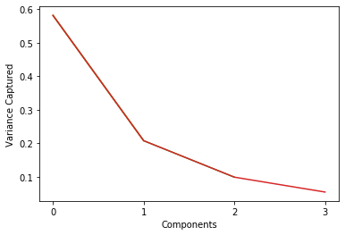

```python
comp = [1,2,3,4]
for i in comp:
    pca = PCA(n_components=i)
    pca.fit(X_train)
    variance = pca.explained_variance_ratio_
    print(sum(variance),i)
    plt.plot(variance)
    plt.xlabel('Components')
    plt.ylabel('Variance Captured')
    plt.xticks(range(0,4))
```

### Linear Regression - PCA

```python
reg = LinearRegression()
```

```python
reg.fit(X_train_pca,y_train)
```

```
LinearRegression(copy_X=True, fit_intercept=True, n_jobs=None, normalize=False)
```

```python
p_train = reg.predict(X_train_pca)
regpca_rmse_train = sqrt(mean_squared_error(y_train,p_train))
regpca_r2_train = r2_score(y_train,p_train)
print('Linear Regression RMSE on Training Data:\n',round(reg_rmse_train,2))
print('Linear Regression R-squared on Training Set:\n',reg_r2_train)
print('\n\nLinear Regression PCA RMSE on Training Data:\n',round(regpca_rmse_train,2))
print('Linear Regression PCA R-squared on Training Set:\n',regpca_r2_train)
```

```
Linear Regression RMSE on Training Data:
 1.31
Linear Regression R-squared on Training Set:
 0.6468752136774542


Linear Regression PCA RMSE on Training Data:
 1.38
Linear Regression PCA R-squared on Training Set:
 0.6128523714371702
```

```python
p_train = reg.predict(X_val_pca)
regpca_rmse_test = sqrt(mean_squared_error(y_val,p_train))
regpca_r2_test = r2_score(y_val,p_train)
print('Linear Regression RMSE on Testing Set:\n',round(rf_rmse_test_best,2))
print('Linear Regression R-squared on Testing Set:\n',rf_r2_test_best)
print('\n\nLinear Regression PCA RMSE on Test Set:\n',round(reg_rmse_test,2))
print('Linear Regression PCA R-squared on Test Set:\n',reg_r2_test)
```

```
Linear Regression RMSE on Testing Set:
 1.18
Linear Regression R-squared on Testing Set:
 0.7330660711403466


Linear Regression PCA RMSE on Test Set:
 1.39
Linear Regression PCA R-squared on Test Set:
 0.6290818432737131
```

**Comparison from before**

### Random Forest Regression - PCA

```python
reg = RandomForestRegressor(n_estimators=100)
```

```python
reg.fit(X_train_pca, y_train)
```

```
RandomForestRegressor(bootstrap=True, criterion='mse', max_depth=None,
                      max_features='auto', max_leaf_nodes=None,
                      min_impurity_decrease=0.0, min_impurity_split=None,
                      min_samples_leaf=1, min_samples_split=2,
                      min_weight_fraction_leaf=0.0, n_estimators=100,
                      n_jobs=None, oob_score=False, random_state=None,
                      verbose=0, warm_start=False)
```

```python
p_train = reg.predict(X_train_pca)
rfpca_rmse_train = sqrt(mean_squared_error(y_train,p_train))
rfpca_r2_train = r2_score(y_train,p_train)
print('Random Forest RMSE on Training Data:\n',round(rf_rmse_train,2))
print('Random Forest R-squared on Training Set:\n',rf_r2_train)

print('\n\nRandom Forest PCA RMSE on Training Data:\n',round(rfpca_rmse_train,2))
print('Random Forest PCA R-squared on Training Set:\n',rfpca_r2_train)
```

```
Random Forest RMSE on Training Data:
 0.45
Random Forest R-squared on Training Set:
 0.9594121515222038


Random Forest PCA RMSE on Training Data:
 0.44
Random Forest PCA R-squared on Training Set:
 0.9596622427552384
```

```python
p_validation = reg.predict(X_val_pca)
rfpca_rmse_test = sqrt(mean_squared_error(y_val,p_validation))
rfpca_r2_test = r2_score(y_val,p_validation)
print('Random Forest RMSE on Testing Data:\n',round(rf_rmse_test,2))
print('Random Forest R-squared on Testing Set:\n',rf_r2_test)

print('\n\nRandom Forest PCA RMSE on Test Set:\n',round(rfpca_rmse_test,2))
print('Random Forest PCA R-squared on Test Set:\n',rfpca_r2_test)
```

```
Random Forest RMSE on Testing Data:
 1.14
Random Forest R-squared on Testing Set:
 0.7493450154104488


Random Forest PCA RMSE on Test Set:
 1.23
Random Forest PCA R-squared on Test Set:
 0.712195788388724
```

**Comparison from before**

As we can see, random forest performed slightly worse under PCA.

### RBF Kernel SVM Regressor - PCA

```python
reg = SVR(kernel='rbf')
```

```python
reg.fit(X_train_pca, y_train)
```

```
SVR(C=1.0, cache_size=200, coef0=0.0, degree=3, epsilon=0.1,
    gamma='auto_deprecated', kernel='rbf', max_iter=-1, shrinking=True,
    tol=0.001, verbose=False)
```

```python
p_train = reg.predict(X_train_pca)
svrrbfpca_rmse_train = sqrt(mean_squared_error(y_train,p_train))
svrrbfpca_r2_train = r2_score(y_train,p_train)
print('SVR RBF PCA RMSE on Training Data:\n',round(svrrbfpca_rmse_train,2))
print('SVR RBF PCA R-squared on Training Set:\n',svrrbfpca_r2_train)

print('\n\nSVR RBF RMSE on Training Data:\n',round(svrrbf_rmse_train,2))
print('SVR RBF R-squared on Training Set:\n',svrrbf_r2_train)
```

```
SVR RBF PCA RMSE on Training Data:
 1.13
SVR RBF PCA R-squared on Training Set:
 0.7391631087866246


SVR RBF RMSE on Training Data:
 1.1
SVR RBF R-squared on Training Set:
 0.7537814347693681
```

```python
p_validation = reg.predict(X_val_pca)
svrrbfpca_rmse_test = sqrt(mean_squared_error(y_val,p_validation))
svrrbfpca_r2_test = r2_score(y_val,p_validation)
print('SVR RBF PCA RMSE on Test Set:\n',round(svrrbfpca_rmse_test,2))
print('SVR RBF PCA R-squared on Test Set:\n',svrrbfpca_r2_test)

print('\n\nSVR RBF RMSE on Testing Set:\n',round(svrrbf_rmse_test,2))
print('SVR RBF R-squared on Testing Set:\n',svrrbf_rmse_test)
```

```
SVR RBF PCA RMSE on Test Set:
 1.3
SVR RBF PCA R-squared on Test Set:
 0.6767736167733687


SVR RBF RMSE on Testing Set:
 0.72
SVR RBF R-squared on Testing Set:
 0.7239434577070454
```

**Comparison from before**

As we can see, svr performed worse under PCA.

##### Parameter tuning of RBF Kernel SVM using the PCA data

### RBF Kernel SVM Regressor - PCA Parameter Tuning

```python
reg = SVR(kernel='rbf')
```

```python
parameter = {"C": [20],"gamma":[.1,.15,.30,10],"degree":[.0001,.001,.01]}
```

```python
grid_cv_svrrbf_pca_reg = GridSearchCV(estimator = reg ,param_grid = parameter,cv = 5) #depth = parameter
```

```python
grid_cv_svrrbf_pca_reg.fit(X_train_pca, y_train)
```

```
GridSearchCV(cv=5, error_score='raise-deprecating',
             estimator=SVR(C=1.0, cache_size=200, coef0=0.0, degree=3,
                           epsilon=0.1, gamma='auto_deprecated', kernel='rbf',
                           max_iter=-1, shrinking=True, tol=0.001,
                           verbose=False),
             iid='warn', n_jobs=None,
             param_grid={'C': [20], 'degree': [0.0001, 0.001, 0.01],
                         'gamma': [0.1, 0.15, 0.3, 10]},
             pre_dispatch='2*n_jobs', refit=True, return_train_score=False,
             scoring=None, verbose=0)
```

```python
grid_cv_svrrbf_pca_reg.cv_results_
```

[output not shown]

[output cut: 8 more lines]

```
        0.82732401, 0.80001687, 0.60893179, 0.83874144, 0.82732401,
        0.80001687, 0.60893179]),
 'split3_test_score': array([0.58879248, 0.58982053, 0.59477975, 0.47042343, 0.58879248,
        0.58982053, 0.59477975, 0.47042343, 0.58879248, 0.58982053,
        0.59477975, 0.47042343]),
 'split4_test_score': array([0.75325842, 0.75398077, 0.74776445, 0.53353339, 0.75325842,
        0.75398077, 0.74776445, 0.53353339, 0.75325842, 0.75398077,
        0.74776445, 0.53353339]),
 'mean_test_score': array([0.74382566, 0.74293713, 0.7378477 , 0.54915497, 0.74382566,
        0.74293713, 0.7378477 , 0.54915497, 0.74382566, 0.74293713,
        0.7378477 , 0.54915497]),
 'std_test_score': array([0.08763477, 0.08538503, 0.0792637 , 0.05293526, 0.08763477,
        0.08538503, 0.0792637 , 0.05293526, 0.08763477, 0.08538503,
        0.0792637 , 0.05293526]),
 'rank_test_score': array([ 1,  4,  7, 10,  1,  4,  7, 10,  1,  4,  7, 10])}
```

```python
grid_cv_svrrbf_pca_reg.best_estimator_
```

```
SVR(C=20, cache_size=200, coef0=0.0, degree=0.0001, epsilon=0.1, gamma=0.1,
    kernel='rbf', max_iter=-1, shrinking=True, tol=0.001, verbose=False)
```

```python
svrpca_reg_best = grid_cv_svrrbf_pca_reg.best_estimator_
```

```python
svrpca_reg_best.fit(X_train_pca,y_train)
```

```
SVR(C=20, cache_size=200, coef0=0.0, degree=0.0001, epsilon=0.1, gamma=0.1,
    kernel='rbf', max_iter=-1, shrinking=True, tol=0.001, verbose=False)
```

```python
p_train = svrpca_reg_best.predict(X_train_pca)
svrrbfpca_rmse_train_best = sqrt(mean_squared_error(y_train,p_train))
svrrbfpca_r2_train_best = r2_score(y_train,p_train)
print('Parameter Tune SVR RBF PCA Training Data:\n',round(svrrbfpca_rmse_train_best,2))
print('Parameter Tune SVR RBF PCA R-squared on Training Set:\n',svrrbfpca_r2_train_best)


print('\n\nSVR RBF PCA RMSE on Training Data:\n',round(svrrbfpca_rmse_train,2))
print('SVR RBF PCA R-squared on Training Set:\n',svrrbfpca_r2_train)
```

```
Parameter Tune SVR RBF PCA Training Data:
 1.11
Parameter Tune SVR RBF PCA R-squared on Training Set:
 0.7482027924814205


SVR RBF PCA RMSE on Training Data:
 1.13
SVR RBF PCA R-squared on Training Set:
 0.7391631087866246
```

```python
p_validation = svrpca_reg_best.predict(X_val_pca)
svrrbfpca_rmse_test_best = sqrt(mean_squared_error(y_val,p_validation))
svrrbfpca_r2_test_best = r2_score(y_val,p_validation)
print('Parameter Tune SVR RBF PCA RMSE on Testing Data:\n',round(svrrbfpca_rmse_test_best,2))
print('Parameter Tune SVR RBF PCA R-squared on Testing Set:\n',svrrbfpca_r2_test_best)


print('\n\nSVR RBF PCA RMSE on Test Set:\n',round(svrrbfpca_rmse_test,2))
print('SVR RBF PCA R-squared on Test Set:\n',svrrbfpca_r2_test)
```

```
Parameter Tune SVR RBF PCA RMSE on Testing Data:
 1.24
Parameter Tune SVR RBF PCA R-squared on Testing Set:
 0.7048600821927726


SVR RBF PCA RMSE on Test Set:
 1.3
SVR RBF PCA R-squared on Test Set:
 0.6767736167733687
```

**Comparison from before**

As we can see, the parameter tuning of svr performed slightly better with the parameter tuning.

## Q6 [10]

- Apply Kernel PCA (KPCA) and transform the data.
- Take the first 30 kernel principal components.(In KPCA you will (in many cases) have more dimensions than your original number of features!)
- Use the KPCA transformed data to perform regression.
- Now apply Linear Regression, Random Forest Regression, and RBF Kernel Support Vector Regression. For each model:
  - What is the model $R^2$?
  - What is the $R^2$ on validation data?
  - What is the RMSE on training data?
  - What is the RMSE on validation data?
- Compare these models with their results obtained before. For example: Compare SVR with SVR from before. Use the best hyperparameters obtained from the experiments before.
  - Is there any change in performance when compared to models trained on original data? Please explain.
  - Is there any change in performance when compared to models trained on PCA transformed data? Please explain.
- Perform hyperparameter tuning of SVR using KPCA transformed data. Any improvement?

```python
from sklearn.decomposition import KernelPCA
```

```python
kpca = KernelPCA(n_components=100, kernel='rbf', n_jobs=-1, remove_zero_eig=True)
kpca.fit(X_train)
X_train_kpca = kpca.transform(X_train)
X_val_kpca = kpca.transform(X_val)
```

```python
X_train_kpca = X_train_kpca[:, 0:30]
X_val_kpca = X_val_kpca[:, 0:30]
```

### Linear Regression - KPCA

```python
reg = LinearRegression()
```

```python
reg.fit(X_train_kpca,y_train)
```

```
LinearRegression(copy_X=True, fit_intercept=True, n_jobs=None, normalize=False)
```

```python
p_train = reg.predict(X_train_kpca)
regkpca_rmse_train = sqrt(mean_squared_error(y_train,p_train))
regkpca_r2_train = r2_score(y_train,p_train)
print('Linear Regression KPCA RMSE on Training Data:\n',round(regkpca_rmse_train,2))
print('Linear Regression KPCA R-squared on Training Set:\n',regkpca_r2_train)

print('\n\nLinear Regression PCA RMSE on Training Data:\n',round(regpca_rmse_train,2))
print('Linear Regression PCA R-squared on Training Set:\n',regpca_r2_train)
```

```
Linear Regression KPCA RMSE on Training Data:
 1.13
Linear Regression KPCA R-squared on Training Set:
 0.7367356216476463


Linear Regression PCA RMSE on Training Data:
 1.38
Linear Regression PCA R-squared on Training Set:
 0.6128523714371702
```

```python
p_validation = reg.predict(X_val_kpca)
regkpca_rmse_test = sqrt(mean_squared_error(y_val,p_validation))
regkpca_r2_test = r2_score(y_val,p_validation)
print('Linear Regression KPCA RMSE on Test Data:\n',round(regkpca_rmse_test,2))
print('Linear Regression KPCA R-squared on Test Data:\n',regkpca_r2_test)

print('\n\nLinear Regression PCA RMSE on Test Data:\n',round(regpca_rmse_test,2))
print('Linear Regression PCA R-squared on Test Set:\n',regpca_r2_test)
```

```
Linear Regression KPCA RMSE on Test Data:
 1.24
Linear Regression KPCA R-squared on Test Data:
 0.7067752703974686


Linear Regression PCA RMSE on Test Data:
 1.46
Linear Regression PCA R-squared on Test Set:
 0.5925986135843699
```

**Comparison from before**

As we can see, linear regression performed much better under KPCA.

### Random Forest Regression - KPCA

```python
reg = RandomForestRegressor(n_estimators=100)
```

```python
reg.fit(X_train_kpca, y_train)
```

```
RandomForestRegressor(bootstrap=True, criterion='mse', max_depth=None,
                      max_features='auto', max_leaf_nodes=None,
                      min_impurity_decrease=0.0, min_impurity_split=None,
                      min_samples_leaf=1, min_samples_split=2,
                      min_weight_fraction_leaf=0.0, n_estimators=100,
                      n_jobs=None, oob_score=False, random_state=None,
                      verbose=0, warm_start=False)
```

```python
p_train = reg.predict(X_train_kpca)
rfkpca_rmse_train = sqrt(mean_squared_error(y_train,p_train))
rfkpca_r2_train = r2_score(y_train,p_train)
print('\n\nRandom Forest KPCA RMSE on Training Data:\n',round(rfkpca_rmse_train,2))
print('Random Forest KPCA R-squared on Training Set:\n',rfkpca_r2_train)

print('\n\nRandom Forest PCA RMSE on Training Data:\n',round(rf_rmse_train,2))
print('Random Forest PCA R-squared on Training Set:\n',rf_r2_train)
```

```
Random Forest KPCA RMSE on Training Data:
 0.42
Random Forest KPCA R-squared on Training Set:
 0.9632553018375889


Random Forest PCA RMSE on Training Data:
 0.45
Random Forest PCA R-squared on Training Set:
 0.9594121515222038
```

```python
p_train = reg.predict(X_val_kpca)
rfkpca_rmse_test = sqrt(mean_squared_error(y_val,p_train))
rfkpca_r2_test = r2_score(y_val,p_train)
print('Random Forest KPCA RMSE on Test Set:\n',round(rfkpca_rmse_test,2))
print('Random Forest KPCA R-squared on Test Set:\n',rfkpca_r2_test)

print('\n\nRandom Forest PCA RMSE on Test Data:\n',round(rf_rmse_test,2))
print('Random Forest PCA R-squared on Test Set:\n',rf_r2_test)
```

```
Random Forest KPCA RMSE on Test Set:
 1.16
Random Forest KPCA R-squared on Test Set:
 0.7418941439008468


Random Forest PCA RMSE on Test Data:
 1.14
Random Forest PCA R-squared on Test Set:
 0.7493450154104488
```

**Comparison from before**

As we can see, random forest performed slightly worse under KPCA.

### RBF Kernel SVM Regressor - KPCA

```python
reg = SVR(kernel='rbf')
```

```python
reg.fit(X_train_kpca, y_train)
```

```
SVR(C=1.0, cache_size=200, coef0=0.0, degree=3, epsilon=0.1,
    gamma='auto_deprecated', kernel='rbf', max_iter=-1, shrinking=True,
    tol=0.001, verbose=False)
```

```python
p_train = reg.predict(X_train_kpca)
svrrbfkpca_rmse_train = sqrt(mean_squared_error(y_train,p_train))
svrrbfkpca_r2_train = r2_score(y_train,p_train)
print('SVR RBF KPCA RMSE on Training Set:\n',round(svrrbfkpca_rmse_train,2))
print('SVR RBF KPCA R-squared on Training Set:\n',svrrbfkpca_r2_train)

print('\n\nSVR RBF PCA RMSE on Training Set:\n',round(svrrbfpca_rmse_test,2))
print('SVR RBF PCA R-squared on Training Set:\n',svrrbfpca_r2_test)
```

```
SVR RBF KPCA RMSE on Training Set:
 1.28
SVR RBF KPCA R-squared on Training Set:
 0.6658754730554829


SVR RBF PCA RMSE on Training Set:
 1.3
SVR RBF PCA R-squared on Training Set:
 0.6767736167733687
```

```python
p_validation = reg.predict(X_train_kpca)
svrrbfkpca_rmse_test = sqrt(mean_squared_error(y_train,p_validation))
svrrbfkpca_r2_test = r2_score(y_train,p_train)
print('SVR RBF KPCA RMSE on Test Set:\n',round(svrrbfkpca_rmse_test,2))
print('SVR RBF KPCA R-squared on Test Set:\n',svrrbfkpca_r2_test)

print('\n\nSVR RBF PCA RMSE on Test Set:\n',round(svrrbfpca_rmse_train,2))
print('SVR RBF PCA R-squared on Test Set:\n',svrrbfpca_r2_train)
```

```
SVR RBF KPCA RMSE on Test Set:
 1.28
SVR RBF KPCA R-squared on Test Set:
 0.6658754730554829


SVR RBF PCA RMSE on Test Set:
 1.13
SVR RBF PCA R-squared on Test Set:
 0.7391631087866246
```

**Comparison from before**

As we can see, svr rbf KPCA performed worse under KPCA.

### Parameter tuning of RBF Kernel SVM using KPCA data

```python
reg = SVR(kernel='rbf')
```

```python
parameter = {"C": [20],"gamma":[.1,.15,.30,10],"degree":[.0001,.001,.01]}
```

```python
grid_cv_svrrbf_kpca_reg = GridSearchCV(estimator = reg ,param_grid = parameter,cv = 5) #depth = parameter
```

```python
grid_cv_svrrbf_kpca_reg.fit(X_train_kpca, y_train)
```

```
GridSearchCV(cv=5, error_score='raise-deprecating',
             estimator=SVR(C=1.0, cache_size=200, coef0=0.0, degree=3,
                           epsilon=0.1, gamma='auto_deprecated', kernel='rbf',
                           max_iter=-1, shrinking=True, tol=0.001,
                           verbose=False),
             iid='warn', n_jobs=None,
             param_grid={'C': [20], 'degree': [0.0001, 0.001, 0.01],
                         'gamma': [0.1, 0.15, 0.3, 10]},
             pre_dispatch='2*n_jobs', refit=True, return_train_score=False,
             scoring=None, verbose=0)
```

```python
grid_cv_svrrbf_kpca_reg.cv_results_
```

[output not shown]

[output cut: 8 more lines]

```
        0.8382205 , 0.84527278, 0.75964695, 0.83443359, 0.8382205 ,
        0.84527278, 0.75964695]),
 'split3_test_score': array([0.60175667, 0.60357621, 0.60429947, 0.57865041, 0.60175667,
        0.60357621, 0.60429947, 0.57865041, 0.60175667, 0.60357621,
        0.60429947, 0.57865041]),
 'split4_test_score': array([0.75912257, 0.75993433, 0.76003387, 0.72665075, 0.75912257,
        0.75993433, 0.76003387, 0.72665075, 0.75912257, 0.75993433,
        0.76003387, 0.72665075]),
 'mean_test_score': array([0.74901053, 0.75109343, 0.75326603, 0.71672462, 0.74901053,
        0.75109343, 0.75326603, 0.71672462, 0.74901053, 0.75109343,
        0.75326603, 0.71672462]),
 'std_test_score': array([0.08493463, 0.08555506, 0.08724071, 0.07865655, 0.08493463,
        0.08555506, 0.08724071, 0.07865655, 0.08493463, 0.08555506,
        0.08724071, 0.07865655]),
 'rank_test_score': array([ 7,  4,  1, 10,  7,  4,  1, 10,  7,  4,  1, 10])}
```

```python
grid_cv_svrrbf_kpca_reg.best_estimator_
```

```
SVR(C=20, cache_size=200, coef0=0.0, degree=0.0001, epsilon=0.1, gamma=0.3,
    kernel='rbf', max_iter=-1, shrinking=True, tol=0.001, verbose=False)
```

```python
svrkpca_reg_best = grid_cv_svrrbf_kpca_reg.best_estimator_
```

```python
svrkpca_reg_best.fit(X_train_kpca,y_train)
```

```
SVR(C=20, cache_size=200, coef0=0.0, degree=0.0001, epsilon=0.1, gamma=0.3,
    kernel='rbf', max_iter=-1, shrinking=True, tol=0.001, verbose=False)
```

```python
p_train = svrkpca_reg_best.predict(X_train_kpca)
svrrbfkpca_rmse_train_best = sqrt(mean_squared_error(y_train,p_train))
svrrbfkpca_r2_train_best = r2_score(y_train,p_train)
print('\n\nSVR RBF KPCA RMSE on Training Data:\n',round(svrrbfkpca_rmse_train_best,2))
print('SVR RBF KPCA R-squared on Training Set:\n',svrrbfpca_r2_train)


print('\n\nParameter Tune SVR RBF PCA Training Data:\n',round(svrrbfpca_rmse_train_best,2))
print('Parameter Tune SVR RBF PCA R-squared on Training Set:\n',svrrbfpca_r2_train_best)
```

```
SVR RBF KPCA RMSE on Training Data:
 1.1
SVR RBF KPCA R-squared on Training Set:
 0.7391631087866246


Parameter Tune SVR RBF PCA Training Data:
 1.11
Parameter Tune SVR RBF PCA R-squared on Training Set:
 0.7482027924814205
```

```python
p_val = svrkpca_reg_best.predict(X_val_kpca)
svrrbfkpca_rmse_test_best = sqrt(mean_squared_error(y_val,p_val))
svrrbfkpca_r2_test_best = r2_score(y_val,p_val)
print('SVR RBF KPCA Param Tuned RMSE on Test Data:\n',round(svrrbfkpca_rmse_test_best,2))
print('SVR RBF KPCA Param Tuned R-squared on Tesr Set:\n',svrrbfkpca_r2_test_best)


print('\n\nSVR RBF KPCA RMSE on Test Set:\n',round(svrrbfkpca_rmse_test,2))
print('SVR RBF KPCA R-squared on Test Set:\n',svrrbfkpca_r2_test)
```

```
SVR RBF KPCA Param Tuned RMSE on Test Data:
 1.17
SVR RBF KPCA Param Tuned R-squared on Tesr Set:
 0.7365861798743432


SVR RBF KPCA RMSE on Test Set:
 1.28
SVR RBF KPCA R-squared on Test Set:
 0.6658754730554829
```

**Comparison From Before**

As we can see, parameter tuning imporved performance of SVR RBF on KPCA

## Q7 [10]

#### Let's do some classification

We will convert CO target values into binary form by comparing them to a threshold. $ 0 - 3 mg/m^3$ is the range of max 8-hour avg. ambient CO in most US cities. So let's take that.  
[CO Levels of Concern in Government Recommendations and Regulations](https://www.carbonmonoxidekills.com/are-you-at-risk/carbon-monoxide-levels/)

```python
from sklearn.preprocessing import Binarizer
```

```python
binarizer = Binarizer(threshold=3)
```

```python
binarizer.fit([y_train])
y_train_cat = binarizer.transform([y_train]).ravel()
y_val_cat = binarizer.transform([y_val]).ravel()
y_test_cat = binarizer.transform([y_test]).ravel()
```

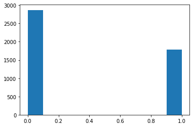

```python
plt.hist(y_train_cat.ravel());
```

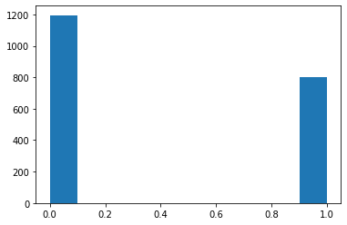

```python
plt.hist(y_val_cat.ravel());
```

#### 1.

- Initiate the Support Vector Classifier from the sklearn library. Use RBF Kernel SVM classifier with default parameters. (No need to specify anything)
- Fit the model using the standardized data. Make sure you use the categorized target variable for classification.
- Make predictions
- Calculate accuracy score. What are the **training** and **testing** accuracies of the model?
- Create confusion matrix
- Either using the confusion matrix or the methods in `sklearn.metrics` get the following metrics on the validation set:
  - Recall (Sensitivity)
  - Specificity
  - Precision
  - Balanced Accuracy
  - F1 Score

#### 2.

- Using the standardized training data perform grid search:
  - Find the best combination of the `C` and `gamma` hyper-parameters.
- For the best model:
  - Either using the confusion matrix or the methods in `sklearn.metrics` get the following metrics on the validation set:
    - Recall (Sensitivity)
    - Specificity
    - Precision
    - Balanced Accuracy
    - F1 Score
  - Compare the results to the model with default parameters. Any change?

#### 3.

- Using the kernel pca transformed training data perform grid search:
  - Find the best combination of the `C` and `gamma` hyper-parameters.
- For the best model:
  - Either using the confusion matrix or the methods in `sklearn.metrics` get the following metrics on the validation set:
    - Recall (Sensitivity)
    - Specificity
    - Precision
    - Balanced Accuracy
    - F1 Score
  - Compare the results to the model using standardized training data (bullet 2). Is there any change in performance?

### Q7 - 1.)

```python
from sklearn.svm import SVC
```

```python
svc = SVC(kernel ='rbf')
```

```python
col_names = []
for i in X:
    col_names.append(i)
print(col_names)
```

```
['AT', 'AP', 'AH', 'AFDP', 'GTEP', 'TIT', 'TAT', 'TEY', 'CDP']
```

```python
#convert back X_train and X_val to pd.datafram
X_train = pd.DataFrame(X_train, columns = col_names)
X_train.head()
```

|  | AT | AP | AH | AFDP | GTEP | TIT | TAT | TEY | CDP |
| --- | --- | --- | --- | --- | --- | --- | --- | --- | --- |
| 0 | 0.426446 | -1.047778 | 1.129238 | 1.157306 | 0.975300 | 1.038156 | -0.648063 | 1.017086 | 1.061000 |
| 1 | 0.267684 | -1.514396 | 0.452768 | 0.060304 | 0.132464 | 0.552925 | 0.595674 | 0.393629 | 0.273224 |
| 2 | 0.350710 | -0.231196 | -0.610929 | -0.125032 | 1.372627 | 0.305254 | 0.608534 | 0.080041 | 0.077602 |
| 3 | 0.092490 | 0.702041 | 0.437211 | -0.291442 | -0.416802 | -0.043506 | 0.603022 | -0.226730 | -0.208782 |
| 4 | 0.238527 | -1.193596 | 1.078659 | 0.281695 | -0.419715 | -0.109215 | 0.614045 | -0.265154 | -0.289850 |

```python
X_val = pd.DataFrame(X_val, columns = col_names)
X_val.head()
```

|  | AT | AP | AH | AFDP | GTEP | TIT | TAT | TEY | CDP |
| --- | --- | --- | --- | --- | --- | --- | --- | --- | --- |
| 0 | 0.152783 | 0.862441 | 0.047919 | -0.418697 | -0.451761 | -0.058670 | 0.689367 | -0.234167 | -0.257247 |
| 1 | -1.939217 | 1.504041 | 0.772902 | -1.466593 | -1.509507 | -1.418329 | 0.569954 | -1.336683 | -1.352554 |
| 2 | 0.876910 | -0.172868 | 0.710011 | 0.461972 | -0.238419 | 0.133401 | 0.670996 | -0.183348 | -0.090703 |
| 3 | 0.115594 | -0.260359 | -0.134414 | -0.170387 | -0.401339 | -0.013179 | 0.625068 | -0.193264 | -0.247554 |
| 4 | -1.353392 | 1.124914 | -0.096222 | 1.379350 | 1.471230 | 1.048265 | -2.773623 | 1.841339 | 1.771231 |

```python
svc.fit(X_train,y_train_cat)
```

```
SVC(C=1.0, cache_size=200, class_weight=None, coef0=0.0,
    decision_function_shape='ovr', degree=3, gamma='auto_deprecated',
    kernel='rbf', max_iter=-1, probability=False, random_state=None,
    shrinking=True, tol=0.001, verbose=False)
```

```python
svc_pred = svc.predict(X_val)
```

```python
print('Train Score',svc.score(X_train,y_train_cat))
```

```
Train Score 0.9213072457536013
```

```python
print('Test Score',svc.score(X_val,y_val_cat))
```

```
Test Score 0.9232698094282848
```

```python
from sklearn.metrics import classification_report
from sklearn.metrics import confusion_matrix
from sklearn.metrics import balanced_accuracy_score
print(classification_report(y_val_cat, svc_pred))
print('Balanced Accuracy:',round(balanced_accuracy_score(y_val_cat, svc_pred),2))
```

```
              precision    recall  f1-score   support

         0.0       0.93      0.94      0.94      1195
         1.0       0.91      0.89      0.90       799

    accuracy                           0.92      1994
   macro avg       0.92      0.92      0.92      1994
weighted avg       0.92      0.92      0.92      1994

Balanced Accuracy: 0.92
```

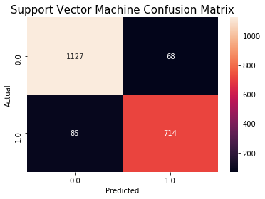

```python
confusion_matrix = pd.crosstab(y_val_cat, svc_pred, rownames=['Actual'], colnames=['Predicted']) #creating confusion matrix
sns.heatmap(confusion_matrix, annot=True, square=False, fmt='', cbar=True)
plt.title("Support Vector Machine Confusion Matrix", fontsize = 15)
plt.show()
```

### Q7 - 2.)

```python
svc = SVC(kernel ='rbf')
```

```python
parameter = {"C":[1,2,4,8],"gamma":[.1,.15,.30,10]}
```

```python
grid_cv_svc = GridSearchCV(estimator = svc ,param_grid = parameter,cv = 5) #depth = parameter
```

```python
grid_cv_svc.fit(X_train, y_train_cat)
```

```
GridSearchCV(cv=5, error_score='raise-deprecating',
             estimator=SVC(C=1.0, cache_size=200, class_weight=None, coef0=0.0,
                           decision_function_shape='ovr', degree=3,
                           gamma='auto_deprecated', kernel='rbf', max_iter=-1,
                           probability=False, random_state=None, shrinking=True,
                           tol=0.001, verbose=False),
             iid='warn', n_jobs=None,
             param_grid={'C': [1, 2, 4, 8], 'gamma': [0.1, 0.15, 0.3, 10]},
             pre_dispatch='2*n_jobs', refit=True, return_train_score=False,
             scoring=None, verbose=0)
```

```python
grid_cv_svc.cv_results_
```

```
{'mean_fit_time': array([0.09928069, 0.09707146, 0.10079393, 0.48358202, 0.09641361,
        0.1009552 , 0.10767922, 0.4730113 , 0.10383077, 0.1016819 ,
        0.10883656, 0.47838964, 0.10592623, 0.10809927, 0.1186666 ,
        0.4825232 ]),
 'std_fit_time': array([0.00750786, 0.00261002, 0.00181411, 0.02067622, 0.00279294,
        0.00587124, 0.00722929, 0.00442773, 0.00378027, 0.005054  ,
        0.00556695, 0.01943145, 0.00392529, 0.0029833 , 0.00589041,
        0.01388682]),
 'mean_score_time': array([0.01504102, 0.01455359, 0.01538358, 0.05445471, 0.01307859,
        0.0147964 , 0.01554475, 0.06441126, 0.0147933 , 0.0141109 ,
        0.01648622, 0.05603714, 0.01436758, 0.01376944, 0.01418571,
        0.05967526]),
 'std_score_time': array([0.00146224, 0.0004828 , 0.00052309, 0.00100061, 0.00418564,
        0.00038869, 0.00048448, 0.01541613, 0.0003835 , 0.0004604 ,
        0.00313804, 0.00116335, 0.00079825, 0.0007268 , 0.00073531,
        0.00855636]),
 'param_C': masked_array(data=[1, 1, 1, 1, 2, 2, 2, 2, 4, 4, 4, 4, 8, 8, 8, 8],
              mask=[False, False, False, False, False, False, False, False,
                    False, False, False, False, False, False, False, False],
        fill_value='?',
             dtype=object),
 'param_gamma': masked_array(data=[0.1, 0.15, 0.3, 10, 0.1, 0.15, 0.3, 10, 0.1, 0.15, 0.3,
                    10, 0.1, 0.15, 0.3, 10],
              mask=[False, False, False, False, False, False, False, False,
                    False, False, False, False, False, False, False, False],
        fill_value='?',
             dtype=object),
 'params': [{'C': 1, 'gamma': 0.1},
  {'C': 1, 'gamma': 0.15},
  {'C': 1, 'gamma': 0.3},
  {'C': 1, 'gamma': 10},
  {'C': 2, 'gamma': 0.1},
  {'C': 2, 'gamma': 0.15},
  {'C': 2, 'gamma': 0.3},
  {'C': 2, 'gamma': 10},
  {'C': 4, 'gamma': 0.1},
  {'C': 4, 'gamma': 0.15},
  {'C': 4, 'gamma': 0.3},
  {'C': 4, 'gamma': 10},
  {'C': 8, 'gamma': 0.1},
```

[output cut: 17 more lines]

```
        0.90860215, 0.86344086, 0.90967742, 0.90860215, 0.91290323,
        0.86236559]),
 'split4_test_score': array([0.92465016, 0.92572659, 0.92357374, 0.87621098, 0.92572659,
        0.92680301, 0.92357374, 0.87621098, 0.92572659, 0.92465016,
        0.92249731, 0.8729817 , 0.92895587, 0.92357374, 0.91280947,
        0.87513455]),
 'mean_test_score': array([0.91743711, 0.91765212, 0.91593206, 0.86540529, 0.91743711,
        0.91614707, 0.91528704, 0.86691034, 0.91593206, 0.91614707,
        0.91593206, 0.86476027, 0.91679209, 0.91593206, 0.91507203,
        0.86476027]),
 'std_test_score': array([0.00662907, 0.00769448, 0.00772426, 0.00803644, 0.00793059,
        0.00766823, 0.00741301, 0.00584222, 0.00647232, 0.00720363,
        0.00659468, 0.0050976 , 0.00883029, 0.00722185, 0.00489074,
        0.00607465]),
 'rank_test_score': array([ 2,  1,  7, 14,  2,  5, 11, 13,  7,  5,  7, 15,  4,  7, 12, 15])}
```

```python
grid_cv_svc.best_estimator_
```

```
SVC(C=1, cache_size=200, class_weight=None, coef0=0.0,
    decision_function_shape='ovr', degree=3, gamma=0.15, kernel='rbf',
    max_iter=-1, probability=False, random_state=None, shrinking=True,
    tol=0.001, verbose=False)
```

```python
svc_best = grid_cv_svc.best_estimator_
```

```python
svc_best.fit(X_train,y_train_cat)
```

```
SVC(C=1, cache_size=200, class_weight=None, coef0=0.0,
    decision_function_shape='ovr', degree=3, gamma=0.15, kernel='rbf',
    max_iter=-1, probability=False, random_state=None, shrinking=True,
    tol=0.001, verbose=False)
```

```python
svc_best_pred = svc_best.predict(X_val)
```

```python
print('Train Score',svc_best.score(X_train, y_train_cat))
```

```
Train Score 0.9213072457536013
```

```python
print('Test Score',svc_best.score(X_val, y_val_cat))
```

```
Test Score 0.9232698094282848
```

```python
print('Best SVM Classifier Classification Report\n',classification_report(y_val_cat, svc_best_pred))
print('Best SVM Classifier Balanced Accuracy:',round(balanced_accuracy_score(y_val_cat, svc_best_pred),2))
print('\n\nOG SVM Classifier Classification Report\n',classification_report(y_val_cat, svc_pred))
print('OG SVM Classifier Balanced Accuracy:',round(balanced_accuracy_score(y_val_cat, svc_pred),2))
```

```
Best SVM Classifier Classification Report
               precision    recall  f1-score   support

         0.0       0.93      0.94      0.94      1195
         1.0       0.91      0.89      0.90       799

    accuracy                           0.92      1994
   macro avg       0.92      0.92      0.92      1994
weighted avg       0.92      0.92      0.92      1994

Best SVM Classifier Balanced Accuracy: 0.92


OG SVM Classifier Classification Report
               precision    recall  f1-score   support

         0.0       0.93      0.94      0.94      1195
         1.0       0.91      0.89      0.90       799

    accuracy                           0.92      1994
   macro avg       0.92      0.92      0.92      1994
weighted avg       0.92      0.92      0.92      1994

OG SVM Classifier Balanced Accuracy: 0.92
```

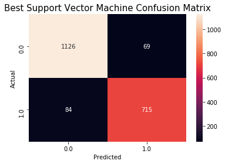

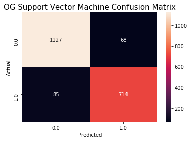

```python
confusion_matrix = pd.crosstab(y_val_cat, svc_best_pred, rownames=['Actual'], colnames=['Predicted']) #creating confusion matrix
sns.heatmap(confusion_matrix, annot=True, square=False, fmt='', cbar=True)
plt.title("Best Support Vector Machine Confusion Matrix", fontsize = 15)
plt.show()

confusion_matrix = pd.crosstab(y_val_cat, svc_pred, rownames=['Actual'], colnames=['Predicted']) #creating confusion matrix
sns.heatmap(confusion_matrix, annot=True, square=False, fmt='', cbar=True)
plt.title("OG Support Vector Machine Confusion Matrix", fontsize = 15)
plt.show()
```

### Q7 - 2.) Analysis

As we can see from the above, there isn't much difference between the original svm, and the best model.

### Q7 - 3.)

```python
X_train_kpca
```

```
array([[ 0.49316459,  0.05578506,  0.20405022, ..., -0.00301984,
         0.01071535,  0.04173479],
       [ 0.13994671, -0.38139921, -0.02927682, ..., -0.01030752,
        -0.03282399, -0.04521759],
       [ 0.20545159, -0.34796572, -0.07294399, ...,  0.02260943,
         0.15715219, -0.04516591],
       ...,
       [ 0.2300507 , -0.41400311, -0.02869271, ..., -0.01336979,
        -0.02166387, -0.01464142],
       [ 0.66983141, -0.00555812, -0.25935818, ...,  0.01544813,
        -0.03186721, -0.02110401],
       [ 0.52810659, -0.13503738, -0.39142986, ...,  0.01942821,
        -0.02728643, -0.03124216]])
```

```python
X_val_kpca
```

```
array([[-0.31564101, -0.39055174,  0.121133  , ..., -0.03372457,
         0.04891646, -0.00137497],
       [-0.40232164,  0.40888755, -0.01531771, ..., -0.12035016,
         0.06019645,  0.09294237],
       [-0.02582841, -0.46435162, -0.0120371 , ...,  0.01578917,
         0.05792779,  0.00998099],
       ...,
       [-0.45595191,  0.53365876, -0.26367135, ..., -0.04825697,
         0.00916582, -0.00283456],
       [-0.43074756, -0.28456234,  0.25774468, ..., -0.0219907 ,
        -0.05071185, -0.0136359 ],
       [ 0.26674855,  0.11056432,  0.45880797, ...,  0.09214475,
         0.05101456,  0.12796907]])
```

```python
parameter = {"C":[1,2,4,8],"gamma":[.1,.15,.30,10]}
```

```python
svc = SVC(kernel ='rbf')
```

```python
grid_cv_svc_kpca = GridSearchCV(estimator = svc ,param_grid = parameter,cv = 5) #depth = parameter
```

```python
grid_cv_svc_kpca.fit(X_train_kpca, y_train_cat)
```

```
GridSearchCV(cv=5, error_score='raise-deprecating',
             estimator=SVC(C=1.0, cache_size=200, class_weight=None, coef0=0.0,
                           decision_function_shape='ovr', degree=3,
                           gamma='auto_deprecated', kernel='rbf', max_iter=-1,
                           probability=False, random_state=None, shrinking=True,
                           tol=0.001, verbose=False),
             iid='warn', n_jobs=None,
             param_grid={'C': [1, 2, 4, 8], 'gamma': [0.1, 0.15, 0.3, 10]},
             pre_dispatch='2*n_jobs', refit=True, return_train_score=False,
             scoring=None, verbose=0)
```

```python
grid_cv_svc_kpca.best_estimator_
```

```
SVC(C=8, cache_size=200, class_weight=None, coef0=0.0,
    decision_function_shape='ovr', degree=3, gamma=0.15, kernel='rbf',
    max_iter=-1, probability=False, random_state=None, shrinking=True,
    tol=0.001, verbose=False)
```

```python
svc_best_kpca = grid_cv_svc_kpca.best_estimator_
```

```python
svc_best_pred_kpca = svc_best_kpca.predict(X_val_kpca)
```

```python
print('Train Score',svc_best_kpca.score(X_train_kpca, y_train_cat))
```

```
Train Score 0.9167920877230703
```

```python
print('Test Score',svc_best_kpca.score(X_val_kpca, y_val_cat))
```

```
Test Score 0.9197592778335005
```

```python
print('Best SVM KPCA Classifier Classification Report\n',classification_report(y_val_cat, svc_best_pred_kpca))
print('Best SVM KPCA Classifier Balanced Accuracy:',round(balanced_accuracy_score(y_val_cat, svc_best_pred_kpca),2))

print('\n\nBest SVM Classifier Classification Report\n',classification_report(y_val_cat, svc_best_pred))
print('Best SVM Classifier Balanced Accuracy:',round(balanced_accuracy_score(y_val_cat, svc_best_pred),2))
```

```
Best SVM KPCA Classifier Classification Report
               precision    recall  f1-score   support

         0.0       0.93      0.94      0.93      1195
         1.0       0.90      0.89      0.90       799

    accuracy                           0.92      1994
   macro avg       0.92      0.92      0.92      1994
weighted avg       0.92      0.92      0.92      1994

Best SVM KPCA Classifier Balanced Accuracy: 0.92


Best SVM Classifier Classification Report
               precision    recall  f1-score   support

         0.0       0.93      0.94      0.94      1195
         1.0       0.91      0.89      0.90       799

    accuracy                           0.92      1994
   macro avg       0.92      0.92      0.92      1994
weighted avg       0.92      0.92      0.92      1994

Best SVM Classifier Balanced Accuracy: 0.92
```

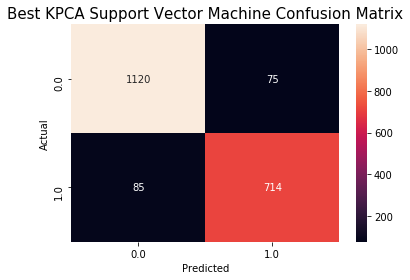

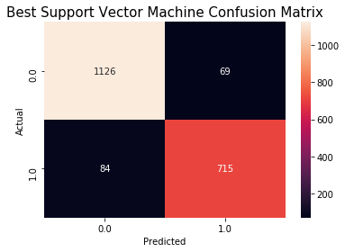

```python
confusion_matrix = pd.crosstab(y_val_cat, svc_best_pred_kpca, rownames=['Actual'], colnames=['Predicted']) #creating confusion matrix
sns.heatmap(confusion_matrix, annot=True, square=False, fmt='', cbar=True)
plt.title("Best KPCA Support Vector Machine Confusion Matrix", fontsize = 15)
plt.show()


confusion_matrix = pd.crosstab(y_val_cat, svc_best_pred, rownames=['Actual'], colnames=['Predicted']) #creating confusion matrix
sns.heatmap(confusion_matrix, annot=True, square=False, fmt='', cbar=True)
plt.title("Best Support Vector Machine Confusion Matrix", fontsize = 15)
plt.show()
```

### Q7 - 3.)

As shown above, we can see the results are still somewhat similar between the two support vector models.

## Q8 [10]

- Using the Support Vector Regressor (Any of them):
  - Think of other ways of improving the regression performance and list at least two possibilities.
  - You can use any of the datasets we have been using, or re-create your own set from the original.
  - Implement both of the methods you proposed.
  - Is the validation performance increasing? For performance comparison you can use any regression performance metric that you deem to be appropriate.
  - If both of them did not improve, comment on why this might have been the case. What else can be done?
  - Optional: Apply different things as you see fit and see if the validation performance is improving.

**Improving KPCA SVR compared to the originally tuned**

1. Trying larger value of C
2. Trying different values of epsilon

```python
reg = SVR(kernel='rbf')
```

```python
parameter = {"C":[100],"epsilon":[.0001,.001],"gamma":[.01,.1]}
```

```python
grid_cv_svr = GridSearchCV(estimator = reg ,param_grid = parameter,cv = 5) #depth = parameter
```

```python
grid_cv_svr.fit(X_train_kpca, y_train)
```

```
GridSearchCV(cv=5, error_score='raise-deprecating',
             estimator=SVR(C=1.0, cache_size=200, coef0=0.0, degree=3,
                           epsilon=0.1, gamma='auto_deprecated', kernel='rbf',
                           max_iter=-1, shrinking=True, tol=0.001,
                           verbose=False),
             iid='warn', n_jobs=None,
             param_grid={'C': [100], 'epsilon': [0.0001, 0.001],
                         'gamma': [0.01, 0.1]},
             pre_dispatch='2*n_jobs', refit=True, return_train_score=False,
             scoring=None, verbose=0)
```

```python
grid_cv_svr_best = grid_cv_svr.best_estimator_
```

```python
grid_cv_svr_best.fit(X_train_kpca,y_train)
```

```
SVR(C=100, cache_size=200, coef0=0.0, degree=3, epsilon=0.0001, gamma=0.1,
    kernel='rbf', max_iter=-1, shrinking=True, tol=0.001, verbose=False)
```

```python
p_svrval = grid_cv_svr_best.predict(X_val_kpca)
svrrbf_rmse_test_best = sqrt(mean_squared_error(y_val,p_svrval))
svrrbf_r2_test_best = r2_score(y_val,p_svrval)
print('RMSE on Testing Data:\n',round(svrrbf_rmse_test_best,2))
print('R-squared on Testing Set:\n',svrrbf_r2_test_best)

print('\n\nSVR RBF KPCA OG Param Tuned RMSE on Test Data:\n',round(svrrbfkpca_rmse_test_best,2))
print('SVR RBF KPCA OG Param Tuned R-squared on Tesr Set:\n',svrrbfkpca_r2_test_best)
```

```
RMSE on Testing Data:
 1.18
R-squared on Testing Set:
 0.7331260858651392


SVR RBF KPCA OG Param Tuned RMSE on Test Data:
 1.17
SVR RBF KPCA OG Param Tuned R-squared on Tesr Set:
 0.7365861798743432
```

Unfortunately, the methods applied di not improve the Rsquared or the RMSE on the test set. A method that could potentially improve this, is an even larger value of C, but that runs the risk of overfitting the data.

## Q9 [10]

- Using the Support Vector Classifier (Any of them):
  - Think of other ways of improving the clasification performance and list at least two possibilities.
  - You can use any of the datasets we have been using, or re-create your own set from the original.
  - Implement both of the methods you proposed.
  - Is the validation performance increasing? For performance comparison you can use any classification performance metric that you deem to be appropriate.
  - If both of them did not improve, comment on why this might have been the case. What else can be done?
  - Use at least 3 more classification models to perform classification. (Logistic Reg, Random Forest, etc. You can choose anything)
    - Perform hyper-parameter tuning on at least one of them.
    - Compare the validation performances with SVC. Which one is better?
  - Optional: Apply different methods as you see fit and see if the validation performance is improving.

```python
svc = SVC(kernel ='rbf')
```

```python
X_train_pca
```

```
array([[ 2.3159228 , -0.07971586, -1.73945172,  0.12365715],
       [ 0.44173122, -1.01638817, -1.35379925,  0.09288993],
       [ 0.68579986, -0.74181646,  0.28577359, -0.08276132],
       ...,
       [ 0.68265581, -0.91647734, -1.14202853, -0.11218384],
       [ 2.44985952, -1.27401731,  0.43255412, -0.29854469],
       [ 1.74982811, -1.84339819,  0.88024622, -0.3953758 ]])
```

```python
X_val_pca
```

```
array([[-0.79036235,  0.08433468,  0.45645198, -0.91793187],
       [-3.54573711,  1.95625486,  0.46778102, -0.41034463],
       [-0.12359518, -0.73599355, -0.70559388, -0.80922028],
       ...,
       [-3.92191923,  0.78551727, -0.79548897,  0.73309327],
       [-1.12865568,  0.73410843, -0.76328295, -0.85984042],
       [ 1.94477915,  1.51458832,  0.08785433, -0.58321662]])
```

```python
svc.fit(X_train_pca,y_train_cat)
```

```
SVC(C=1.0, cache_size=200, class_weight=None, coef0=0.0,
    decision_function_shape='ovr', degree=3, gamma='auto_deprecated',
    kernel='rbf', max_iter=-1, probability=False, random_state=None,
    shrinking=True, tol=0.001, verbose=False)
```

```python
parameter = {"C":[1,2,4,8],"gamma":[.1,.15,.30,10],"coef0":[.1,1,2]}
```

```python
grid_cv_svc_pca = GridSearchCV(estimator = svc ,param_grid = parameter,cv = 5) #depth = parameter
```

```python
grid_cv_svc_pca.fit(X_train_pca,y_train_cat)
```

```
GridSearchCV(cv=5, error_score='raise-deprecating',
             estimator=SVC(C=1.0, cache_size=200, class_weight=None, coef0=0.0,
                           decision_function_shape='ovr', degree=3,
                           gamma='auto_deprecated', kernel='rbf', max_iter=-1,
                           probability=False, random_state=None, shrinking=True,
                           tol=0.001, verbose=False),
             iid='warn', n_jobs=None,
             param_grid={'C': [1, 2, 4, 8], 'coef0': [0.1, 1, 2],
                         'gamma': [0.1, 0.15, 0.3, 10]},
             pre_dispatch='2*n_jobs', refit=True, return_train_score=False,
             scoring=None, verbose=0)
```

```python
grid_cv_svc_pca.best_estimator_
```

```
SVC(C=1, cache_size=200, class_weight=None, coef0=0.1,
    decision_function_shape='ovr', degree=3, gamma=0.15, kernel='rbf',
    max_iter=-1, probability=False, random_state=None, shrinking=True,
    tol=0.001, verbose=False)
```

```python
svc_pca_best = grid_cv_svc_pca.best_estimator_
```

```python
svcpca_best_pred = svc_pca_best.predict(X_val_pca)
```

```python
print(svc_pca_best.score(X_train_pca, y_train_cat))
```

```
0.9176521178241238
```

```python
print(svc_pca_best.score(X_val_pca, y_val_cat))
```

```
0.9147442326980942
```

```python
print('Best SVM PCA Classifier Classification Report\n',classification_report(y_val_cat, svcpca_best_pred))
print('Best SVM PCA Classifier Balanced Accuracy:',round(balanced_accuracy_score(y_val_cat, svcpca_best_pred),2))

print('\n\nBest SVM KPCA Classifier Classification Report\n',classification_report(y_val_cat, svc_best_pred_kpca))
print('Best SVM KPCA Classifier Balanced Accuracy:',round(balanced_accuracy_score(y_val_cat, svc_best_pred_kpca),2))

print('\n\nBest SVM Classifier Classification Report\n',classification_report(y_val_cat, svc_best_pred))
print('Best SVM Classifier Balanced Accuracy:',round(balanced_accuracy_score(y_val_cat, svc_best_pred),2))
```

```
Best SVM PCA Classifier Classification Report
               precision    recall  f1-score   support

         0.0       0.92      0.94      0.93      1195
         1.0       0.90      0.88      0.89       799

    accuracy                           0.91      1994
   macro avg       0.91      0.91      0.91      1994
weighted avg       0.91      0.91      0.91      1994

Best SVM PCA Classifier Balanced Accuracy: 0.91


Best SVM KPCA Classifier Classification Report
               precision    recall  f1-score   support

         0.0       0.93      0.94      0.93      1195
         1.0       0.90      0.89      0.90       799

    accuracy                           0.92      1994
   macro avg       0.92      0.92      0.92      1994
weighted avg       0.92      0.92      0.92      1994

Best SVM KPCA Classifier Balanced Accuracy: 0.92


Best SVM Classifier Classification Report
               precision    recall  f1-score   support

         0.0       0.93      0.94      0.94      1195
         1.0       0.91      0.89      0.90       799

    accuracy                           0.92      1994
   macro avg       0.92      0.92      0.92      1994
weighted avg       0.92      0.92      0.92      1994

Best SVM Classifier Balanced Accuracy: 0.92
```

```python
from sklearn.discriminant_analysis import LinearDiscriminantAnalysis
from sklearn.linear_model import LogisticRegression
from sklearn.ensemble import BaggingClassifier, RandomForestClassifier
```

```python
ldclf = LinearDiscriminantAnalysis()
```

```python
ldclf.fit(X_train_pca,y_train_cat)
ldclfpred_train = ldclf.predict(X_train_pca)
ldclfpred_test = ldclf.predict(X_val_pca)
```

```python
print(ldclf.score(X_train_pca,y_train_cat))
```

```
0.8978714254998925
```

```python
print(ldclf.score(X_val_pca,y_val_cat))
```

```
0.8861584754262788
```

```python
print(classification_report(y_val_cat, ldclfpred_test))
```

```
              precision    recall  f1-score   support

         0.0       0.89      0.93      0.91      1195
         1.0       0.88      0.82      0.85       799

    accuracy                           0.89      1994
   macro avg       0.89      0.88      0.88      1994
weighted avg       0.89      0.89      0.89      1994
```

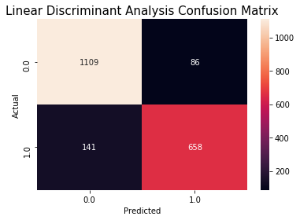

```python
confusion_matrix = pd.crosstab(y_val_cat, ldclfpred_test, rownames=['Actual'], colnames=['Predicted']) #creating confusion matrix
sns.heatmap(confusion_matrix, annot=True, square=False, fmt='', cbar=True)
plt.title("Linear Discriminant Analysis Confusion Matrix", fontsize = 15)
plt.show()
```

```python
logclf = LogisticRegression()#model with default values
```

```python
logclf.fit(X_train_pca, y_train_cat) #fitting our LR model to the training X and y
logpred_train = logclf.predict(X_train_pca)   #predicting our train X with the model
logpred_test = logclf.predict(X_val_pca)
```

```python
print(logclf.score(X_train_pca,y_train_cat))
```

```
0.898731455600946
```

```python
print(logclf.score(X_val_pca,y_val_cat))
```

```
0.8816449348044132
```

```python
print(classification_report(y_val_cat, logpred_test))
```

```
              precision    recall  f1-score   support

         0.0       0.90      0.91      0.90      1195
         1.0       0.86      0.84      0.85       799

    accuracy                           0.88      1994
   macro avg       0.88      0.87      0.88      1994
weighted avg       0.88      0.88      0.88      1994
```

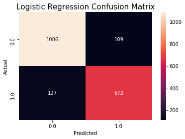

```python
confusion_matrix = pd.crosstab(y_val_cat, logpred_test, rownames=['Actual'], colnames=['Predicted']) #creating the confusion matrix
sns.heatmap(confusion_matrix, annot=True, square=False, fmt='', cbar=True)
plt.title("Logistic Regression Confusion Matrix", fontsize = 15)
plt.show()
```

```python
rfclf = RandomForestClassifier()
```

```python
rfclf.fit(X_train_pca, y_train_cat) #creating the RF classifier and fitting the model with our training data - X and y
rfpred_train = rfclf.predict(X_train_pca)
rfpred_test = rfclf.predict(X_val_pca)
```

```python
print(rfclf.score(X_train_pca,y_train_cat))
```

```
0.9903246613631477
```

```python
rf_testacc = rfclf.score(X_val_pca,y_val_cat)
print(rf_testacc)
```

```
0.9062186559679037
```

```python
print(classification_report(y_val_cat, rfpred_test))
```

```
              precision    recall  f1-score   support

         0.0       0.91      0.94      0.92      1195
         1.0       0.91      0.85      0.88       799

    accuracy                           0.91      1994
   macro avg       0.91      0.90      0.90      1994
weighted avg       0.91      0.91      0.91      1994
```

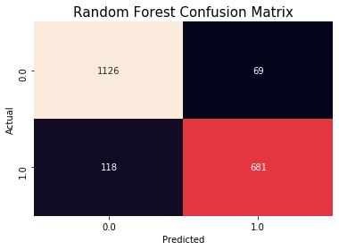

```python
confusion_matrix = pd.crosstab(y_val_cat, rfpred_test, rownames=['Actual'], colnames=['Predicted']) #creating confusion matrix
sns.heatmap(confusion_matrix, annot=True, square=False, fmt='', cbar=False)
plt.title("Random Forest Confusion Matrix", fontsize = 15)
plt.show()

#plotting the predicted classes verses the actual test classes into a matrix
```

### Q9 - Random Forest Parameter Tuning

```python
forest = RandomForestClassifier(criterion = 'entropy',n_jobs=-1)
```

```python
parameter = {'min_samples_split':[2,3,4],'max_depth':[9,10,11],'n_estimators':[58,59,60]}
```

```python
grid_cv_forest = GridSearchCV(estimator = forest ,param_grid = parameter,cv = 5)
grid_cv_forest.fit(X_train_pca,y_train_cat)
```

```
GridSearchCV(cv=5, error_score='raise-deprecating',
             estimator=RandomForestClassifier(bootstrap=True, class_weight=None,
                                              criterion='entropy',
                                              max_depth=None,
                                              max_features='auto',
                                              max_leaf_nodes=None,
                                              min_impurity_decrease=0.0,
                                              min_impurity_split=None,
                                              min_samples_leaf=1,
                                              min_samples_split=2,
                                              min_weight_fraction_leaf=0.0,
                                              n_estimators='warn', n_jobs=-1,
                                              oob_score=False,
                                              random_state=None, verbose=0,
                                              warm_start=False),
             iid='warn', n_jobs=None,
             param_grid={'max_depth': [9, 10, 11],
                         'min_samples_split': [2, 3, 4],
                         'n_estimators': [58, 59, 60]},
             pre_dispatch='2*n_jobs', refit=True, return_train_score=False,
             scoring=None, verbose=0)
```

```python
tuned_forest = grid_cv_forest.best_estimator_
```

```python
tuned_forestclf_best = tuned_forest.fit(X_train_pca,y_train_cat)
```

```python
tuned_forestpreds = tuned_forestclf_best.predict(X_val_pca)
print(tuned_forestpreds)
```

```
[0. 1. 0. ... 1. 0. 0.]
```

```python
print(tuned_forestclf_best.score(X_train_pca,y_train_cat))
```

```
0.9597935927757472
```

```python
print(tuned_forestclf_best.score(X_val_pca,y_val_cat))
```

```
0.9127382146439318
```

```python
print(classification_report(y_val_cat, tuned_forestpreds))
```

```
              precision    recall  f1-score   support

         0.0       0.92      0.93      0.93      1195
         1.0       0.90      0.88      0.89       799

    accuracy                           0.91      1994
   macro avg       0.91      0.91      0.91      1994
weighted avg       0.91      0.91      0.91      1994
```

[figure not shown]

```python
confusion_matrix = pd.crosstab(y_val_cat, rfpred_test, rownames=['Actual'], colnames=['Predicted']) #creating confusion matrix
sns.heatmap(confusion_matrix, annot=True, square=False, fmt='', cbar=True)
plt.title("Tuned Random Forest Confusion Matrix", fontsize = 15)
plt.show()
#plotting the predicted classes verses the actual test classes into a matrix
```

```python
print('Best SVM PCA Classifier\n',classification_report(y_val_cat, svcpca_best_pred))
print('\nLDA PCA Classifier\n',classification_report(y_val_cat, ldclfpred_test))
print('\nLogistic Regression PCA Classifier\n',classification_report(y_val_cat, logpred_test))
print('\nRandom Forest PCA Classifier\n',classification_report(y_val_cat, rfpred_test))
print('\nTuned Random Forest PCA Classifier\n',classification_report(y_val_cat, tuned_forestpreds))
```

```
Best SVM PCA Classifier
               precision    recall  f1-score   support

         0.0       0.92      0.94      0.93      1195
         1.0       0.90      0.88      0.89       799

    accuracy                           0.91      1994
   macro avg       0.91      0.91      0.91      1994
weighted avg       0.91      0.91      0.91      1994


LDA PCA Classifier
               precision    recall  f1-score   support

         0.0       0.89      0.93      0.91      1195
         1.0       0.88      0.82      0.85       799

    accuracy                           0.89      1994
   macro avg       0.89      0.88      0.88      1994
weighted avg       0.89      0.89      0.89      1994


Logistic Regression PCA Classifier
               precision    recall  f1-score   support

         0.0       0.90      0.91      0.90      1195
         1.0       0.86      0.84      0.85       799

    accuracy                           0.88      1994
   macro avg       0.88      0.87      0.88      1994
weighted avg       0.88      0.88      0.88      1994


Random Forest PCA Classifier
               precision    recall  f1-score   support

         0.0       0.91      0.94      0.92      1195
         1.0       0.91      0.85      0.88       799

    accuracy                           0.91      1994
   macro avg       0.91      0.90      0.90      1994
weighted avg       0.91      0.91      0.91      1994


Tuned Random Forest PCA Classifier
               precision    recall  f1-score   support

         0.0       0.92      0.93      0.93      1195
         1.0       0.90      0.88      0.89       799

    accuracy                           0.91      1994
   macro avg       0.91      0.91      0.91      1994
weighted avg       0.91      0.91      0.91      1994
```

## Q10 [10]

- Choose the best fitted model from each of the regressors (1 from Linear Regression, 1 from Random Forest, 1 from SVR)
- Create a table summarizing results on the **test** set:
  - Show the regression performance metric of your choice on test data for each model.
- Which model is best for regression? Is this in line with your analysis or is this not expected?
- Choose the best fitted model from each of the classifiers (1 from RBF Kernel SVC, 1 from each of the models you have used)
- Create a table summarizing results on the **test** set:
  - Show the classification performance metric of your choice on test data for each model.
- Which model is best for classification? Is this in line with your analysis or is this not expected?
- What did you learn in this project?

We will use the below models for the **best regression models**:

1. OG Linear Regression
2. KPCA Random Forest
3. SVR RBF Tuned

```python
#Linear Regression
reg = LinearRegression()
```

```python
reg.fit(X_train, y_train)
```

```
LinearRegression(copy_X=True, fit_intercept=True, n_jobs=None, normalize=False)
```

```python
#KPCA Random Forest
forreg = RandomForestRegressor(n_estimators=100)
```

```python
forreg.fit(X_train_kpca, y_train)
```

```
RandomForestRegressor(bootstrap=True, criterion='mse', max_depth=None,
                      max_features='auto', max_leaf_nodes=None,
                      min_impurity_decrease=0.0, min_impurity_split=None,
                      min_samples_leaf=1, min_samples_split=2,
                      min_weight_fraction_leaf=0.0, n_estimators=100,
                      n_jobs=None, oob_score=False, random_state=None,
                      verbose=0, warm_start=False)
```

```python
svr_reg_best = grid_cv_svrrbf_reg.best_estimator_
```

```python
svr_reg_best.fit(X_train,y_train)
```

```
SVR(C=20, cache_size=200, coef0=0.0, degree=0.0001, epsilon=0.1, gamma=0.1,
    kernel='rbf', max_iter=-1, shrinking=True, tol=0.001, verbose=False)
```

```python
#Regression
p_validation = reg.predict(X_val)
reg_rmse_test = sqrt(mean_squared_error(y_val,p_validation))
reg_r2_test = r2_score(y_val,p_validation)
print('Linear Regression RMSE on Test Set:\n',round(reg_rmse_test,2))
print('Linear Regression R-squared on Test Set:\n',reg_r2_test)

#KPCA Random Forest Regression
p_forestval = forreg.predict(X_val_kpca)
rfkpca_rmse_test = sqrt(mean_squared_error(y_val,p_forestval))
rfkpca_r2_test = r2_score(y_val,p_forestval)
print('\n\nRandom Forest KPCA RMSE on Test Set:\n',round(rfkpca_rmse_test,2))
print('Random Forest KPCA R-squared on Test Set:\n',rfkpca_r2_test)

#SVR RBF Tuned
p_svrval = svr_reg_best.predict(X_val)
svrrbf_rmse_test_best = sqrt(mean_squared_error(y_val,p_svrval))
svrrbf_r2_test_best = r2_score(y_val,p_svrval)
print('\n\nSVR RBF RMSE on Test Set:\n',round(svrrbf_rmse_test_best,2))
print('SVR RBF R-squared on Test Set:\n',svrrbf_r2_test_best)
```

```
Linear Regression RMSE on Test Set:
 1.39
Linear Regression R-squared on Test Set:
 0.6290818432737131


Random Forest KPCA RMSE on Test Set:
 1.17
Random Forest KPCA R-squared on Test Set:
 0.739333506015159


SVR RBF RMSE on Test Set:
 1.18
SVR RBF R-squared on Test Set:
 0.7348406867576343
```

**Which model is best for regression? Is this in line with your analysis or is this not expected?**

The model I found best for regression was the random forest KPCA and the SVR RBF. Both had nearly the same RMSE and R-squared on the test set. I was suprised that the tuned SVR RBF performed so well, because other SVR methods (linear and polynomial) did not perform so well.

We will use the below models for the **best classification models**:

1. OG SVC RBF
2. PCA Random Forest Tuned

```python
print('OG SVM Classifier Classification Report\n',classification_report(y_val_cat, svc_pred))
print('OG SVM Classifier Balanced Accuracy:',round(balanced_accuracy_score(y_val_cat, svc_pred),2))
print('\nTuned Random Forest PCA Classifier\n',classification_report(y_val_cat, tuned_forestpreds))
print('Tuned Random Forest Balanced Accuracy:',round(balanced_accuracy_score(y_val_cat, svc_pred),2))
```

[output not shown]

**Which model is best for classification? Is this in line with your analysis or is this not expected?**

The models that I found best for performing classification was the original svm classifier, and the tuned random forest. I did not expect that the original svm classifier with no parameter tuning would perform so well.

**What did you learn in this project?**

During this project, I learned that you can correct overfitting in random forest regression with tuning hyperparameters.I also learned, that a higher value of "C" in svm can improve rsquareds, but can also lead to overfitting. Overall I believe I learned more about SVM in general as well, and how RBF, in this case performed stronger than linear and polynomial.